[figure not shown]

# Tumblr API

### Corso di Social Media Management

#### Student tutorial a cura di Sergio Maccarrone - X81000448

[figure not shown]

# Tumblr API

## Indice

- Tumblr: Cos'è e perchè è stato scelto?
- Accesso alle Tumblr API
- API Rest: cosa sono?
- API Rest Tumblr: struttura e metodi richiamabili
- Wrapper Pytumblr
- Pytumblr: uso e metodi
- Pytumblr: esempio
- Conclusioni

# Tumblr API

## Cos'è Tumblr

Tumblr è una piattaforma di microblogging e social networking che consente di creare un tumblelog offrendo la possibilità all'utenza di creare un blog dove postare contenuti multimediali. Tumblr è stato lanciato nel febbraio 2007 e nel giro di due settimane il servizio ha raggiunto 75.000 utenti. Nel 2013 Yahoo! ha acquistato Tumblr con un'offerta di 1,1 miliardi di dollari. Nel dicembre 2018, alcune settimane dopo l'eliminazione dell'app per Tumblr dall'App Store, la piattaforma ha comunicato di essere intenzionata a eliminare tutti i contenuti ritenuti per adulti, per via di critiche sugli standard applicati nel controllo dei contenuti. Queste restrizioni hanno contemporaneamente suscitato le proteste di molti utenti, poiché a loro dire andrebbero a penalizzare ingiustamente contenuti artistici o scientifici. È stato calcolato che, in seguito a questa politica, nei primi mesi del 2019 Tumblr abbia perso 437 milioni di visite totali alle proprie pagine. Ad agosto 2019, Verizon cede Tumblr ad Automattic, società che controlla il Cms web open source WordPress.

## Perchè Tumblr

E' stato scelto Tumblr perchè è l'esempio di come un social network che prende una decisione drastica come quella di eliminare e bloccare tutti i blog che condividevano contenuti sensibili possa avere delle ripercussioni così gravi da perdere svariati milioni di utenti attivi nella propria piattaforma. Inoltre, la scelta è stata guidata dal fatto che Tumblr è sempre stato un social in cui ogni utente può essere se stesso dal momento che non ha un contatto uno ad uno con altri utenti ma semplicemente ha la possibilità di condividere contenuti nel proprio blog senza che vengano mostrati dati personali, dunque, si elimina l'idea comune di avere un profilo (in questo caso blog) che debba essere molto curato che possa avere ripercussioni nella vita sociale dell'utente. In questi anni Tumblr è stato utile per molti ragazzi che hanno avuto la possibilità condividere pensieri intimi con il resto del mondo senza esserne giudicati. Questo è possibile perchè non è presente il concetto di amicizia all'interno della piattaforma, dunque, i lettori del proprio blog saranno persone di tutto il mondo che condividono la stessa passione o interesse.

# Tumblr API

## Cosa sono delle API

Il primo passo per analizzare i contenuti multimediali di Tumblr è l'estrapolazione di tali dati dal social network. Per fare ciò si ha bisogno delle API, cioè un insieme di procedure atte all'espletamento di un dato compito. Tumblr come molte altre piattaforme fornisce un insieme di API che permettono l'integrazione di funzionalità a degli applicativi che interagiscono con il suddetto social. Questo permette ai programmatori di evitare l'utilizzo di API realizzate da terzi.

## Come ottenere le API di Tumblr

E' possibile verificare il funzionamento delle API collegandosi al seguente [link](https://api.tumblr.com/console/calls/user/info) inserendo la consumer key e la consumer secret.La pagina mostrerà la console messa a disposizione da Tumblr per eseguire delle prove utilizzando le chiamate API.

[output not shown]

# Tumblt API

## API Rest: cosa sono?

## Cosa si intende con la parola Rest?

Quando si parla di Rest (Representational State Transfer) ci si riferisce a un’architettura software. Questo approccio architetturale venne ideato per creare web API basandosi sul protocollo HTTP. Il REST è infatti un sistema di trasmissione dei dati che utilizza l’HTTP e che fa un grande uso delle funzioni di HTTP, ricorrendo ai comandi GET, POST, PUT, PATCH, DELETE e OPTIONS grazie ai quali si riesce ad identificare ben precise risorse presenti in tutto il web.

## I princìpi del REST

Il REST si compone da una serie di vincoli e princìpi: • Client-server: essi hanno compiti tra loro ben definiti e dedicati. Ognuno di loro si occupa di ben determinati aspetti e funzionalità, evitando così qualsiasi accavallamento di competenze; • Stateless: questo principio si basa sull’assenza di stato durante la comunicazione tra server e client. Questo comporta che ogni sessione client-server è unica, mai correlata alle precedenti o a quelle future; • Cacheable: questo principio permette di memorizzare i dati forniti dal server all'interno di una cache. Le risposte date dal server devono essere esplicitamente etichettate come memorizzabili nella cache o meno: in questo modo si evita che i client usino stati vecchi o addirittura errati; • Layered system: Rest è un sistema basato su livelli composti da server distribuiti che garantiscono i vari servizi sopracitati. • Uniform interface: interfaccia dei server e dei client è uniforme e omogenea, facile da utilizzare e perfetta se si vuole semplificare l’architettura; • Code on demand: Rest consente di aggiornare la logica dei client senza dover aggiornare obbligatoriamente anche quella dei server.

## API Rest: perché usarle?

L’API REST, sono delle API che seguono i princìpi Rest e che per funzionare ricorrono ai comandi dell’HTTP sopracitati. I dati di ritorno saranno in JSON.

#### I vantaggi dell’utilizzo delle API Rest

• Indipendenza: le API Rest sono indipendenti dai linguaggi o da precise piattaforme. Si possono avere server che utilizzano qualsiasi linguaggiio di programmazione senza riscontrare alcun problema nel loro utilizzo. • Separazione client-server: grazie a tale separazione si possono trattare indipendentemente le diverse componenti. Dunque, è modificare solo una parte progettuale senza, per questo, essere obbligati a mettere mano sia al server che al client. • Scalabilità: la separazione client-server si traduce in una miglior scalabilità del sistema stesso.

In conclusione possiamo utilizzare le API Rest per richiedere delle risorse ad un server definendo un URI (sequenza di caratteri che identifica universalmente ed univocamente una risorsa).

# Tumblt API

## API Rest Tumblr: struttura e metodi richiamabili

## Struttura URI

Tutte le richieste API di Tumblr iniziano con *https://api.tumblr.com.* Il segmento successivo del percorso dell'URI dipende dal tipo di richiesta che si desidera effettuare. Vediamo insieme alcuni metodi che possono essere inseriti nelle richieste:

- /info: questo metodo restituisce informazioni generali sul blog, come il titolo, la descrizione, se è possibile seguirlo o contattarlo, l'immagine di profilo, il numero di post e altri dati di alto livello.
- /avatar: questo metodo restituisce l'immagine di profilo del bog inserito, opzionalmente si può aggiungere "/#size", dove attraverso #size è possibile definire la dimensione dell'immagine che si sta richiedendo, il valore deve essere uno dei seguenti [16, 24, 30, 40, 48, 64, 96, 128, 512].
- /likes: questo metodo ritorna i mi piace messi dal blog.
- /following: questo metodo ritorna i blog seguiti.
- /followers: questo metodo ritorna i follower del blog.
- /posts: questo metodo ritorna i post del blog. Ad esso può essere concatenato "\type" che può assumere uno dei seguenti valori [text; photo; link; chat; audio; video;] questo permetterà di ritornare solo i post del tipo inserito.

#### Seguiranno alcuni esempi di utilizzo di chiamate API Rest

```
Blog info:

{
    "meta": {
        "msg": "OK",
        "status": 200,
        "x_tumblr_content_rating": "adult"
    },
    "response": {
        "blog": {
            "ask": true,
            "ask_anon": false,
            "ask_page_title": "Ask me anything",
            "asks_allow_media": true,
            "avatar": [
                {
                    "height": 512,
                    "url": "https://assets.tumblr.com/images/default_avatar/cone_open_512.png",
                    "width": 512
                },
                {
                    "height": 128,
                    "url": "https://assets.tumblr.com/images/default_avatar/cone_open_128.png",
                    "width": 128
                },
                {
                    "height": 96,
                    "url": "https://assets.tumblr.com/images/default_avatar/cone_open_96.png",
                    "width": 96
                },
                {
                    "height": 64,
                    "url": "https://assets.tumblr.com/images/default_avatar/cone_open_64.png",
                    "width": 64
                }
            ],
            "can_chat": true,
            "can_subscribe": false,
            "description": "Blog per scopi didattici",
            "is_nsfw": true,
```

[output cut: 23 more lines]

```
                "title_font": "Gibson",
                "title_font_weight": "bold"
            },
            "title": "BigMac",
            "total_posts": 7,
            "updated": 1606258408,
            "url": "https://sergioct98.tumblr.com/",
            "uuid": "t:0OiIvOoTUK__6tggVRcHvw"
        }
    }
}

-----------------------------------------------------------------------------------------------------------------------

Blog avatar:
```

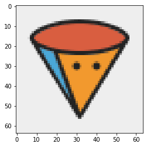

```python
import json
from urllib.request import urlopen as uRequest

#metodo: info-------------------------------------------------------------------------------------------------------------------
print("Blog info: \n")
x=uRequest('https://api.tumblr.com/v2/blog/sergioct98.tumblr.com/info?api_key=GTWFIFiJKuQYG8S9Xl5HfFCUQi5oqr7lEQwupIcgEaG6fCJCPr')
content=json.load(x)
print (json.dumps(content, sort_keys=True, indent=4))

print("\n-----------------------------------------------------------------------------------------------------------------------\n")

#metodo: avatar-----------------------------------------------------------------------------------------------------------------
import matplotlib.pyplot as plt
import matplotlib.image as mpimg
print("Blog avatar: \n")
x=uRequest('https://api.tumblr.com/v2/blog/sergioct98.tumblr.com/avatar')
plt.imshow(mpimg.imread(x))
#print("\n-----------------------------------------------------------------------------------------------------------------------\n")

#metodo: likes-------------------------------------------------------------------------------------------------------------------
#print("Blog likes: \n")
#x=uRequest('https://api.tumblr.com/v2/blog/anankeofyou.tumblr.com/likes?api_key=GTWFIFiJKuQYG8S9Xl5HfFCUQi5oqr7lEQwupIcgEaG6fCJCPr')
#content=json.load(x)
#print (json.dumps(content, sort_keys=True, indent=4))
#print("\n-----------------------------------------------------------------------------------------------------------------------\n")

#metodo: post-------------------------------------------------------------------------------------------------------------------
#print("Blog posts: \n")
#x=uRequest('https://api.tumblr.com/v2/blog/sergioct98.tumblr.com/posts?api_key=GTWFIFiJKuQYG8S9Xl5HfFCUQi5oqr7lEQwupIcgEaG6fCJCPr')
#content=json.load(x)
#print (json.dumps(content, sort_keys=True, indent=4))
#print("\n-----------------------------------------------------------------------------------------------------------------------\n")
```

# Tumblr API

## API Wrapper

Oltre alle chiamate API Rest, Tumblr mette a disposizione una serie di wrapper che forniscono una serie di metodi utili per l'utilizzo delle API. Tra i vari linguaggi per cui è stato creato un wrapper abbiamo Python, PHP, JAVA, Javascript, Ruby, GO e Objective-C

## Cos'è un API wrapper?

Un wrapper API è un pacchetto specifico per un determinato linguaggio di programmazione, esso incapsula le chiamate API in dei metodi utilizzabili all'interno del codice rendendo semplici funzioni complicate. Dunque, esso aiuta gli sviluppatori a chiamare varie API senza la necessità di andare a definire le varie chiamate.

## Pytumblr

Tra i vari wrapper messi a disposizione da Tumblr c'è Pytumblr, che come si può intuire dal nome è il wrapper per Python, esso permette di effettuare chiamate API andando ad utilizzare dei semplici metodi che ritornano le informazioni richieste.

#### Il primo passo per utilizzare Pytumblr è installarlo

Per installarlo bisogna lanciare il seguente comando: *pip install pytubmlr*

```python
pip install pytumblr
```

# Tumblr API

## Pytumblr: uso e metodi

## Pytumblr: uso

Una volta scaricato Pytumblr si può cominciare a creare la propria applicazione. Il link alla documentazione si trova al seguente [link](https://github.com/tumblr/pytumblr)  
Per prima cosa bisogna definire l'oggetto tramite il quale sarà possibile effettuere tutte le chiamate all'API di Tumblr. Per crearlo bisogna richiamare il metodo pytumblr.TumblrRestClient() a cui passare la *consumer_key*, la *consumer_secret*, l'*oauth_token* e l'*oauth_secret*, esse sono disponibili al seguente [link](https://api.tumblr.com/console/calls/user/info) previa inserimento del consumer key e consumer secret disponibili nella propria sezione delle application create.  
Una volta fatto ciò è possibile richiamare i vari metodi disponibili da Pytumblr.

## Metodi richiamabili:

Essi si suddividono in 2 categorie:

- **User methods:** utili per richiedere informazioni riguardanti le info dell'utente che sta effettuando le chiamate API:
  - .info(): ritorna le informazioni riguardanti l'utente
  - .dashboard(): ritorna la dashboard
  - .likes(): ritorna i *mi piace* messi
  - .following(): ritorna i blog *seguiti* dall'utente
  - .follow('#blog'): permette di *seguire* il blog passato al metodo
  - .unfollow('#blog'): permette di smettere di *seguire* il blog passato al metodo
  - .like(#id_post, 'reblog_key')permette di mettere *mi piace* al post identificato dall'id passato
  - .unlike(#id_post, 'reblog_key'): permette di rimuovere il *mi piace* al post identificato dall'id passato
- **Blog methods:** utili per richiedere informazioni riguardanti le info di un determinato blog:
  - .blog_info('#blog_name'): ritorna le informazioni riguardanti il blog inserito
  - .posts('#blog_name',#param): ritorna i post publicati dal blog specificato, si possono inoltre aggiungere dei parametri come ad esempio *reblog_info=True* e *notes_info=True* che permettono di ricevere delle informazioni riguardanti le note relative ai singoli post e le informazioni riguardanti i reblog effettuarti sul post
  - .avatar('#blog_name'): ritorna l'avatar del blog inserito
  - .blog_likes('#blog_name'): ritorna i mi piace del blog inserito
  - .followers('#blog_name'): ritorna i followers del blog inserito
  - .blog_following('#blog_name'): ritorna i i follow pubblici del blog inserito
  - .create_text('#blog_name', state="published", slug="testing-text-posts", title="#title", body="#text"): permette di creare un nuovo post di tipo testo, esso avrà titolo e body uguale a quello inserito nella chiamat API
  - .delete_post('#blog_name',#id_post): esegue la cancellazione del post con id uguale a quello specificato nella chiamata.

```python
#Blog methods

import pytumblr
import json
# Authenticate via OAuth
client = pytumblr.TumblrRestClient(
  'GTWFIFiJKuQYG8S9Xl5HfFCUQi5oqr7lEQwupIcgEaG6fCJCPr',
  '37FOyIrFl3rxSh6dmg6XhGx1TH2IzSc1hjSkJnxSMgFC9W0kQ3',
  '1HzYwuuvY2Ggbl2lVBtuN145SGTtaPJXKTFtrEtoLGA7G4Jvtd',
  '0SrIA1TfRejIhVQxeJEla7F9UMJp5TMeXoybuDHO8T7vWsqRQS'
)

# info()
print("Info method \n")
info=client.info()
print (json.dumps(info, sort_keys=True, indent=4))
print("\n-----------------------------------------------------------------------------------------------------------------------\n")

# dashboard()
#print("Dashboard method \n")
#dashboard=client.dashboard()
#print (json.dumps(dashboard, sort_keys=True, indent=4))
#print("\n-----------------------------------------------------------------------------------------------------------------------\n")

# likes()
#print("Likes method \n")
#likes=client.likes()
#print (json.dumps(likes, sort_keys=True, indent=4))
#print("\n-----------------------------------------------------------------------------------------------------------------------\n")

# following()
print("Following method \n")
following=client.following()
print (json.dumps(following, sort_keys=True, indent=4))
print("\n-----------------------------------------------------------------------------------------------------------------------\n")

# unfollow()
#print("Unfollow method \n")
#unfollow=client.unfollow("#blog_link")
#print (json.dumps(unfollow, sort_keys=True, indent=4))
#print("\n")
#print("\n-----------------------------------------------------------------------------------------------------------------------\n")

# follow()
#print("follow method \n")
#follow=client.follow("#blog_link")
#print (json.dumps(follow, sort_keys=True, indent=4))
#print("\n")
#print("\n-----------------------------------------------------------------------------------------------------------------------\n")

# like()
#print("like method \n")
#like=client.like(numberid,"#reblog_key")#questi valori sono visibili andando a richiedere il post attraverso le API
#print (json.dumps(like, sort_keys=True, indent=4))
#print("\n")
#print("\n-----------------------------------------------------------------------------------------------------------------------\n")

# unlike()
#print("unlike method \n")
#unlike=client.unlike(numberid,"#reblog_key")#questi valori sono visibili andando a richiedere il post attraverso le API
#print (json.dumps(unlike, sort_keys=True, indent=4))
#print("\n")
#print("\n-----------------------------------------------------------------------------------------------------------------------\n")
```

```
Info method

{
    "user": {
        "blogs": [
            {
                "admin": true,
                "ask": true,
                "ask_anon": false,
                "ask_page_title": "Ask me anything",
                "asks_allow_media": true,
                "avatar": [
                    {
                        "height": 512,
                        "url": "https://assets.tumblr.com/images/default_avatar/cone_open_512.png",
                        "width": 512
                    },
                    {
                        "height": 128,
                        "url": "https://assets.tumblr.com/images/default_avatar/cone_open_128.png",
                        "width": 128
                    },
                    {
                        "height": 96,
                        "url": "https://assets.tumblr.com/images/default_avatar/cone_open_96.png",
                        "width": 96
                    },
                    {
                        "height": 64,
                        "url": "https://assets.tumblr.com/images/default_avatar/cone_open_64.png",
                        "width": 64
                    }
                ],
                "can_chat": true,
                "can_send_fan_mail": true,
                "can_subscribe": false,
                "description": "Blog per scopi didattici",
                "drafts": 0,
                "facebook": "N",
                "facebook_opengraph_enabled": "N",
```

[output cut: 126 more lines]

```
            "uuid": "t:zeEPAB5F-I52riYZspRs_g"
        },
        {
            "description": "21 ~Sicily~",
            "name": "anankeofyou",
            "title": "conta se vivi non se esisti",
            "updated": 1567195258,
            "url": "https://anankeofyou.tumblr.com/",
            "uuid": "t:uRqEZz2dm3I2-ii2xeE9Lg"
        }
    ],
    "total_blogs": 13
}

-----------------------------------------------------------------------------------------------------------------------
```

```python
#User methods

import pytumblr
import json
# Authenticate via OAuth
client = pytumblr.TumblrRestClient(
  'GTWFIFiJKuQYG8S9Xl5HfFCUQi5oqr7lEQwupIcgEaG6fCJCPr',
  '37FOyIrFl3rxSh6dmg6XhGx1TH2IzSc1hjSkJnxSMgFC9W0kQ3',
  '1HzYwuuvY2Ggbl2lVBtuN145SGTtaPJXKTFtrEtoLGA7G4Jvtd',
  '0SrIA1TfRejIhVQxeJEla7F9UMJp5TMeXoybuDHO8T7vWsqRQS'
)

# blog_info()
#print("Blog_info method \n")
#blog_info=client.blog_info('sergioct98')
#print (json.dumps(blog_info, sort_keys=True, indent=4))
#print("\n")
#print("\n-----------------------------------------------------------------------------------------------------------------------\n")

# posts()
#print("Posts method \n")
#posts=client.posts('sergioct98')#variante client.posts('sergioct98', reblog_info=True, notes_info=True)
#print (json.dumps(posts, sort_keys=True, indent=4))
#print("\n-----------------------------------------------------------------------------------------------------------------------\n")

# avatar()
#print("Avatar method \n")
#avatar=client.avatar('sergioct98')
#print (json.dumps(avatar, sort_keys=True, indent=4))
#print("\n")
#print("\n-----------------------------------------------------------------------------------------------------------------------\n")

# blog_likes()
#print("Blog_likes method \n")
#blog_likes=client.blog_likes('sergioct98')
#print (json.dumps(blog_likes, sort_keys=True, indent=4))
#print("\n-----------------------------------------------------------------------------------------------------------------------\n")

# followers()
print("Followers method \n")
followers=client.followers('sergioct98')
print (json.dumps(followers, sort_keys=True, indent=4))
print("\n")
print("\n-----------------------------------------------------------------------------------------------------------------------\n")

# blog_following()
print("Blog_following method \n")
blog_following=client.blog_following('sergioct98')
print (json.dumps(blog_following, sort_keys=True, indent=4))
print("\n")
print("\n-----------------------------------------------------------------------------------------------------------------------\n")

#Creazione di un nuovo post di tipo testo
#print("Create a new post")
#client.create_text('sergioct98', state="published", slug="testing-text-posts", title="Testing", body="testing1 2 3 4")
#print("\n-----------------------------------------------------------------------------------------------------------------------\n")

#Eliminazione di un post
#print("Delete a post")
#client.delete_post('sergioct98', 635708017166483457) #il secondo parametro è l'id del post
#print("\n-----------------------------------------------------------------------------------------------------------------------\n")
```

```
Followers method

{
    "total_users": 9,
    "users": [
        {
            "following": true,
            "name": "martastrano",
            "updated": 1603301161,
            "url": "https://martastrano.tumblr.com/"
        },
        {
            "following": true,
            "name": "someonefillsme",
            "updated": 1606398479,
            "url": "https://someonefillsme.tumblr.com/"
        },
        {
            "following": true,
            "name": "anankeofyou",
            "updated": 1567195258,
            "url": "https://anankeofyou.tumblr.com/"
        },
        {
            "following": false,
            "name": "fragilae",
            "updated": 1606916395,
            "url": "https://fragilae.tumblr.com/"
        },
        {
            "following": false,
            "name": "euohorias",
            "updated": 1541281573,
            "url": "https://euohorias.tumblr.com/"
        },
        {
            "following": false,
            "name": "itriponclouds",
            "updated": 1454587920,
            "url": "https://itriponclouds.tumblr.com/"
```

[output cut: 84 more lines]

```
        {
            "description": "21 ~Sicily~",
            "name": "anankeofyou",
            "title": "conta se vivi non se esisti",
            "updated": 1567195258,
            "url": "https://anankeofyou.tumblr.com/",
            "uuid": "t:uRqEZz2dm3I2-ii2xeE9Lg"
        }
    ],
    "total_blogs": 13
}



-----------------------------------------------------------------------------------------------------------------------
```

# Tumblr API

## Pytumblr: esempio

## Esempio di utilizzo del wrapper Pytumblr

Nelle slide successive verrà fatto un breve esempio con lo scopo di utilizzare le chiamate API con il wrapper Pytumblr.

#### L'esempio seguirà i seguenti punti:

- Estrazione dei dati dal blog selezionato, nello specifico: followers; follow; post pubblicati; tag utilizzati; interazioni ricevute ed effettuate;.
- Visualizzazione dei dati estratti, utilizzando grafici e tabelle.
- Manipolazione dei dati estratti al fine di comprendere quale sia il blog più affine all'utente. Per semplificare il tutorial si andrà a prendere il blog seguito a cui l'utente abbia messo più mi piace.

**NB:** Tumblr impone dei limiti sulle informazioni che si possono estrarre (post,note,tag), tale limite è fissato a 20. Esistono diversi metodi non ufficiali per risolvere questo problema. Poiché il problema si discosta dall'obiettivo del tutorial si lascia al lettore il compito di introdurre la soluzione in caso di necessità. Ecco un [link](https://stackoverflow.com/questions/47311845/print-more-than-20-posts-from-tumblr-api) dove è presentata una possibile soluzione al problema.

```python
###################################################Estrazione dei dati##########################################################
import pytumblr
import pandas as pd
import json

# Authenticate via OAuth
client = pytumblr.TumblrRestClient(
  'GTWFIFiJKuQYG8S9Xl5HfFCUQi5oqr7lEQwupIcgEaG6fCJCPr',
  '37FOyIrFl3rxSh6dmg6XhGx1TH2IzSc1hjSkJnxSMgFC9W0kQ3',
  '1HzYwuuvY2Ggbl2lVBtuN145SGTtaPJXKTFtrEtoLGA7G4Jvtd',
  '0SrIA1TfRejIhVQxeJEla7F9UMJp5TMeXoybuDHO8T7vWsqRQS'
)

#blog da cui si stanno estraendo le informazioni
blog="sergioct98"

#print("\n-----------------------------------------------------------------------------------------------------------------------\n")

##lettori del blog
#print("Lettori del blog\n")
followers=client.followers(blog)
followers_number=followers["total_users"]
#print(json.dumps(followers, sort_keys=True, indent=4))

#print("\n-----------------------------------------------------------------------------------------------------------------------\n")

##blog seguiti
#print("Blog seguiti\n")
follow=client.following()
follow_number=follow["total_blogs"]
#print(json.dumps(follow, sort_keys=True, indent=4))

#print("\n-----------------------------------------------------------------------------------------------------------------------\n")

##post pubblicati
#print("Post pubblicati\n")
posts_number=client.posts(blog, reblog_info=True, notes_info=True)["total_posts"]

#controllo limite massimo
if posts_number >=20:
    posts_number=19

post_list=[]
for index in range(posts_number):
        post_list.append(client.posts(blog, reblog_info=True, notes_info=True)['posts'][index])
#print(json.dumps(post_list, sort_keys=True, indent=4))

#print("\n-----------------------------------------------------------------------------------------------------------------------\n")

##Estraiamo le tipologie dei post
#print("Tipologie dei post\n")
type_post_list=[]
#tabella con tipologia di post e frequenze, essa verrà utilizzata per mostrare graficamente i dati
type_post_table = pd.DataFrame(columns=['Type','Count'])
for post in post_list:
    type_post=post["type"]
    type_post_list.append(type_post)

#set() utilizzato per rendere univoci i valori della lista passata
type_post_unique=set(type_post_list)

for index in range(len(type_post_unique)):
    type_tmp=type_post_unique.pop()
    type_post_table=type_post_table.append({'Type':type_tmp,'Count':type_post_list.count(type_tmp)},ignore_index=True)

#print(type_post_table)

#print("\n-----------------------------------------------------------------------------------------------------------------------\n")

##Estraiamo le interazioni ricevute nei post dividendole per tipologia
#print("Interazioni ricevute\n")
likes_list=[]
reblog_list=[]
reply_list=[]
notes_total=0
for post in post_list:
    notes_number=post["note_count"]

    #controllo limite massimo
    if notes_number>=20:
        notes_number=19

    notes_total=notes_total+notes_number
    for noteIndex in range(notes_number):
        typeAction=post["notes"][noteIndex]["type"]
        if typeAction=="like":
            likes_list.append(typeAction)
        elif typeAction=="reblog":
            reblog_list.append(typeAction)
        else :
            reply_list.append(typeAction)

#print("\n-----------------------------------------------------------------------------------------------------------------------\n")

##Estraiamo i tag utilizzati nei post contandone la frequenza
import collections

#print("Tag utilizzati dall'utente\n")

#tabella con tipologia di post e frequenze, essa verrà utilizzata per mostrare graficamente i dati
tags_table = pd.DataFrame(columns=['Tag','Count'])
#lista con tutti i tag inseriti dall'utente
tags_post_list=[]
for post in post_list:
    tags_number=len(post["tags"])

    #controllo limite massimo
    if tags_number>=20:
        tags_number=19

    for tagIndex in range(tags_number):
        tags_post_list.append(post["tags"][tagIndex])

#set() utilizzato per rendere univoci i valori della lista passata
tags_unique=set(tags_post_list)

for index in range(len(tags_unique)):
    tag_tmp=tags_unique.pop()
    tags_table=tags_table.append({'Tag':tag_tmp,'Count':tags_post_list.count(tag_tmp)},ignore_index=True)

tags_table=tags_table.sort_values(by=['Count'],ascending=False)
#print(tags_table)

#print("\n-----------------------------------------------------------------------------------------------------------------------\n")

##Estraiamo le interazioni che l'utente ha effettuato con gli altri blog
#print("Post a cui l'utente ha messo mi piace \n")
blog_likes=client.likes()
#print(json.dumps(blog_likes, sort_keys=True, indent=4))

#print("\n-----------------------------------------------------------------------------------------------------------------------\n")
```

```python
#utilizzato per stampare tabelle
pip install tabulate
```

```
Tabella rappresentante i tag e la frequenza con cui sono stati utilizzati

+-----------------------+-------------+
| Tag                   |   Frequenza |
+=======================+=============+
| likeforlike           |           6 |
+-----------------------+-------------+
| tumblraesthetic       |           6 |
+-----------------------+-------------+
| leicaphotography      |           6 |
+-----------------------+-------------+
| likeforfollow         |           6 |
+-----------------------+-------------+
| photo                 |           6 |
+-----------------------+-------------+
| frasi tumblr          |           6 |
+-----------------------+-------------+
| photography           |           6 |
+-----------------------+-------------+
| tumblr                |           6 |
+-----------------------+-------------+
| followme              |           5 |
+-----------------------+-------------+
| tumblrphoto           |           5 |
+-----------------------+-------------+
| follow                |           5 |
+-----------------------+-------------+
| fotografia            |           4 |
+-----------------------+-------------+
| Like                  |           4 |
+-----------------------+-------------+
| Catania               |           4 |
+-----------------------+-------------+
| instaphoto            |           4 |
+-----------------------+-------------+
| citazioni             |           3 |
+-----------------------+-------------+
| Leica                 |           2 |
+-----------------------+-------------+
| like                  |           2 |
```

[output cut: 20 more lines]

```
+-----------------------+-------------+
| Castello Normanno     |           1 |
+-----------------------+-------------+
| Piazza del pebliscito |           1 |
+-----------------------+-------------+
| fotostupende          |           1 |
+-----------------------+-------------+
| Vulcano               |           1 |
+-----------------------+-------------+
| PiazzaBorsellino      |           1 |
+-----------------------+-------------+

-----------------------------------------------------------------------------------------------------------------------

Grafico a donut rappresentante i tipi di post pubblicati dall'utente
```

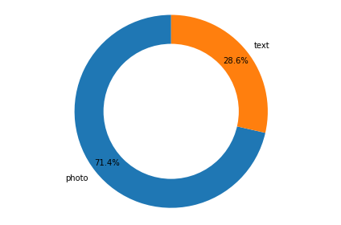

```
-----------------------------------------------------------------------------------------------------------------------

Tabella rappresentante tutte le informazioni che sono state estrapolate

+-----------------------+------------+
| Info                  | Value      |
+=======================+============+
| Blog                  | sergioct98 |
+-----------------------+------------+
| #Follower             | 9          |
+-----------------------+------------+
| #Follow               | 13         |
+-----------------------+------------+
| #Interazioni_ricevute | 34         |
+-----------------------+------------+
| #Like_ricevuti        | 21         |
+-----------------------+------------+
| #Reblog_ricevuti      | 3          |
+-----------------------+------------+
| #Commenti_ricevuti    | 10         |
+-----------------------+------------+
```

```python
#######################################Visualizzazione di alcuni dei dati estrapolati###########################################
from tabulate import tabulate
import matplotlib.pyplot as plt

print("\nTabella rappresentante i tag e la frequenza con cui sono stati utilizzati\n")
header=["Tag","Frequenza"]
print(tabulate(tags_table, headers=header, tablefmt="grid", showindex=False))

print("\n-----------------------------------------------------------------------------------------------------------------------\n")

print("Grafico a donut rappresentante i tipi di post pubblicati dall'utente\n")
#creazione delle variabili utili per mostrare il grafico
labels = type_post_table['Type']
sizes = type_post_table['Count']
fig1, ax1 = plt.subplots()
ax1.pie(sizes, pctdistance=0.85, labels=labels, autopct='%1.1f%%', startangle=90)
centre_circle = plt.Circle((0,0),0.70,fc='white')
fig = plt.gcf()
fig.gca().add_artist(centre_circle)
ax1.axis('equal')
plt.tight_layout()
plt.show()

print("\n-----------------------------------------------------------------------------------------------------------------------\n")

print("Tabella rappresentante tutte le informazioni che sono state estrapolate\n")
header=["Info","Value"]
#lista contenente le info
user_info=pd.DataFrame({"head":["Blog","#Follower","#Follow","#Interazioni_ricevute","#Like_ricevuti","#Reblog_ricevuti","#Commenti_ricevuti"]})
#lista conentente i valori
user_value=pd.DataFrame({"head":[blog , followers_number , follow_number , notes_total , len(likes_list),len(reblog_list),len(reply_list)]})
#tabella da stampare
table_user=pd.DataFrame(columns=["Info","Value"])

for x in range(len(user_info)):
        table_user=table_user.append({"Info":user_info["head"][x],"Value":user_value["head"][x]},ignore_index=True)

print(tabulate(table_user, headers=header, tablefmt="grid", showindex=False))
```

```python
###############################Manipolazione dei dati estratti e conclusioni finali###############################################

#Poiché l'obiettivo dell'esempio è quello di estrarre il blog con cui l'utente ha avuto più interazioni,
#bisogna raffinare le informazioni che sono già in nostro possesso.

#Lista dei blog che l'utente segue
print("\nBlog che l'utente segue: \n")
follow_name=[]
for blogs in follow["blogs"]:
    follow_name.append(blogs["name"])
print(follow_name)

print("\n-----------------------------------------------------------------------------------------------------------------------\n")

#Interazioni che l'utente ha avuto con i blog che segue
print("Blog seguiti a cui l'utente ha messo mi piace ad almeno un post:\n")
blog_notes=[]
for post in blog_likes["liked_posts"]:
    if post["followed"]==True:
        blog_notes.append(post["blog"]["name"])
print(blog_notes)

print("\n-----------------------------------------------------------------------------------------------------------------------\n")

print("Tabella rappresentante il numero di interazioni per ogni blog seguito:\n")

#tabella con blog e mi piace messi
likes_table = pd.DataFrame(columns=['Blog','#Likes'])
header=["Blog","#Likes"]

#rendiamo univoci i blog con cui l'utente ha avuto interazioni
likes_unique=set(blog_notes)

for index in range(len(likes_unique)):
    blog_tmp=likes_unique.pop()
    likes_table=likes_table.append({'Blog':blog_tmp,'#Likes':blog_notes.count(blog_tmp)},ignore_index=True)

likes_table=likes_table.sort_values(by=['#Likes'],ascending=False)

print(tabulate(likes_table, headers=header, tablefmt="grid", showindex=False))

print("\n-----------------------------------------------------------------------------------------------------------------------\n")
#Una volta creata e ordinata la tabella contenente i vari blog seguiti con cui l'utente ha interagito, basterà estrarre il primo
#blog per ottenere il blog più affine.
blog_affine=likes_table.max()
print( blog, "ha maggiore affinità con il blog", blog_affine["Blog"])
```

```
Blog che l'utente segue:

['martastrano', 'marcomaccarronect', 'photo', 'historycultureeducation', 'tokyostreetphoto', 'ups-dogs', 'cafetyong', 'capricorn12-26', 'someonefillsme', 'anankeofyou']

-----------------------------------------------------------------------------------------------------------------------

Blog seguiti a cui l'utente ha messo mi piace ad almeno un post:

['someonefillsme', 'historycultureeducation', 'martastrano', 'someonefillsme', 'someonefillsme', 'someonefillsme']

-----------------------------------------------------------------------------------------------------------------------

Tabella rappresentante il numero di interazioni per ogni blog seguito:

+-------------------------+----------+
| Blog                    |   #Likes |
+=========================+==========+
| someonefillsme          |        4 |
+-------------------------+----------+
| martastrano             |        1 |
+-------------------------+----------+
| historycultureeducation |        1 |
+-------------------------+----------+

-----------------------------------------------------------------------------------------------------------------------

sergioct98 ha maggiore affinità con il blog someonefillsme
```

# Tumblr API

## Conclusioni finali

In questo tutorial sono state trattate le API di Tumblr, distinguendo quelle Rest da quelle richiamabili attraverso il wrapper Pytumblr per il linguaggio Python. Seguendo il tutorial si è visto che per utilizzare le API il primo step è quello di registare una propria applicazione per ottenere le credenziali necessarie per richiedere i dati al social. Inoltre, attraverso il semplice esempio è stato possibile capire quanto le API possano essere uno strumento utilissimo per chi programma, grazie ad esse il processo di estrazione dei dati è stato semplice e veloce.